# Projekt

Projekt koosneb kahest osast:

- turu uuring
- auto TÜ rangesus

```
## Rows: 719,967
## Columns: 14
## $ TEHNOYLEVAATUSPUNKT <chr> "Narva Tehno OÜ (Lääne)", "A-Ülevaatus OÜ (Raua)",…
## $ PUNKTI_KOOD         <chr> "NH", "DR", "LE", "FK", "AX", "AB", "DG", "TU", "R…
## $ TOOTAJA             <chr> "440", "631", "0807", "579", "0885", "0894", "0821…
## $ YV_KUUPAEV          <chr> "2023-12", "2023-07", "2023-06", "2023-10", "2023-…
## $ YLEVAATUSLIIK       <chr> "KORRALINE", "KORRALINE", "KORRALINE", "KORRALINE"…
## $ YLEVAATUSOTSUS      <chr> "KORRAS", "KORRAS", "KORRAS", "KORRAS", "KORRAS", …
## $ RIKKED              <chr> NA, NA, NA, NA, NA, NA, "VO:100103780", NA, NA, NA…
## $ SOIDUK_ID           <dbl> 1, 2, 3, 4, 5, 6, 7, 8, 9, 10, 11, 12, 13, 14, 15,…
## $ ESMANE_REG_AASTA    <dbl> 2003, 2011, 1996, 2015, 2018, 1986, 2004, 2010, 20…
## $ MARK                <chr> "FORD", "PANAV", "HONDA", "KRONE", "VOLKSWAGEN", "…
## $ MUDEL               <chr> "GALAXY", "NS136", "VT 700C", "SDP 27ELB4-CS", "TI…
## $ `mark&model`        <chr> "FORD|GALAXY", "PANAV|NS136", "HONDA|VT 700C", "KR…
## $ KATEGOORIA          <chr> "M1", "O4", "L3e", "O4", "M1G", "O2", "N1", "N1", …
## $ KERETYYP            <chr> "MAHTUNIVERSAAL", "KALLUR", "MOOTORRATAS", "MADEL"…
```

```
## # A tibble: 6 × 14
##   TEHNOYLEVAATUSPUNKT    PUNKTI_KOOD TOOTAJA YV_KUUPAEV YLEVAATUSLIIK
##   <chr>                  <chr>       <chr>   <chr>      <chr>
## 1 Narva Tehno OÜ (Lääne) NH          440     2023-12    KORRALINE
## 2 A-Ülevaatus OÜ (Raua)  DR          631     2023-07    KORRALINE
## 3 Rehvikeskus OÜ         LE          0807    2023-06    KORRALINE
## 4 PRO Tehno OÜ (Sauga)   FK          579     2023-10    KORRALINE
## 5 Tehnotop OÜ            AX          0885    2023-05    KORRALINE
## 6 Tehnoülevaatus OÜ      AB          0894    2023-06    KORRALINE
## # ℹ 9 more variables: YLEVAATUSOTSUS <chr>, RIKKED <chr>, SOIDUK_ID <dbl>,
## #   ESMANE_REG_AASTA <dbl>, MARK <chr>, MUDEL <chr>, `mark&model` <chr>,
## #   KATEGOORIA <chr>, KERETYYP <chr>
```

```
##  [1] "TEHNOYLEVAATUSPUNKT" "PUNKTI_KOOD"         "TOOTAJA"
##  [4] "YV_KUUPAEV"          "YLEVAATUSLIIK"       "YLEVAATUSOTSUS"
##  [7] "RIKKED"              "SOIDUK_ID"           "ESMANE_REG_AASTA"
## [10] "MARK"                "MUDEL"               "mark&model"
## [13] "KATEGOORIA"          "KERETYYP"
```

```
##  TEHNOYLEVAATUSPUNKT PUNKTI_KOOD          TOOTAJA           YV_KUUPAEV
##  Length:719967       Length:719967      Length:719967      Length:719967
##  Class :character    Class :character   Class :character   Class :character
##  Mode  :character    Mode  :character   Mode  :character   Mode  :character
##
##
##
##  YLEVAATUSLIIK      YLEVAATUSOTSUS        RIKKED            SOIDUK_ID
##  Length:719967      Length:719967      Length:719967      Min.   :     1
##  Class :character   Class :character   Class :character   1st Qu.:129218
##  Mode  :character   Mode  :character   Mode  :character   Median :268503
##                                                           Mean   :277083
##                                                           3rd Qu.:420588
##                                                           Max.   :589430
##  ESMANE_REG_AASTA     MARK              MUDEL            mark&model
##  Min.   :1927     Length:719967      Length:719967      Length:719967
##  1st Qu.:2005     Class :character   Class :character   Class :character
##  Median :2008     Mode  :character   Mode  :character   Mode  :character
##  Mean   :2008
##  3rd Qu.:2014
##  Max.   :2023
##   KATEGOORIA          KERETYYP
##  Length:719967      Length:719967
##  Class :character   Class :character
##  Mode  :character   Mode  :character
##
##
##
```

Еsiteks vaatame, kui palju eesti turul firmasid kes teostas TÜ ja kuidas nad jagasid turgu.

```
## # A tibble: 132 × 2
##    PUNKTI_KOOD n_reviews
##    <chr>           <int>
##  1 AS              17991
##  2 MP              17812
##  3 AT              16410
##  4 TT              15062
##  5 MR              14559
##  6 TV              14439
##  7 AN              13531
##  8 BC              12786
##  9 FD              12073
## 10 KD              11533
## # ℹ 122 more rows
```

Kokku on 132 TÜ punkti. Mõned nendes on sama firma all. Aga selliseid on üksikud.

Edasi vaatame millin autode jaotus kategooriate järgi.

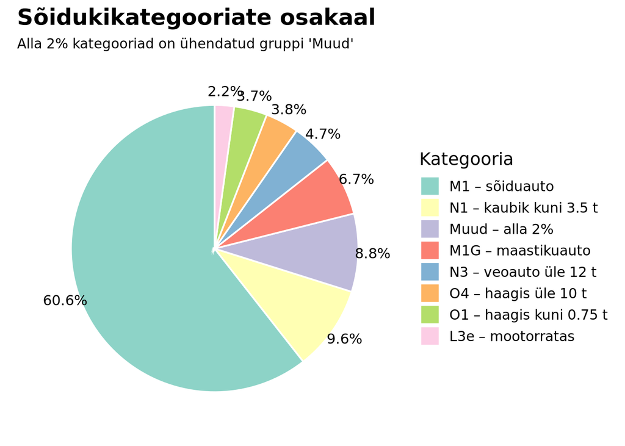

Vaatame, kas TÜ äris kehtib reegel 80/20

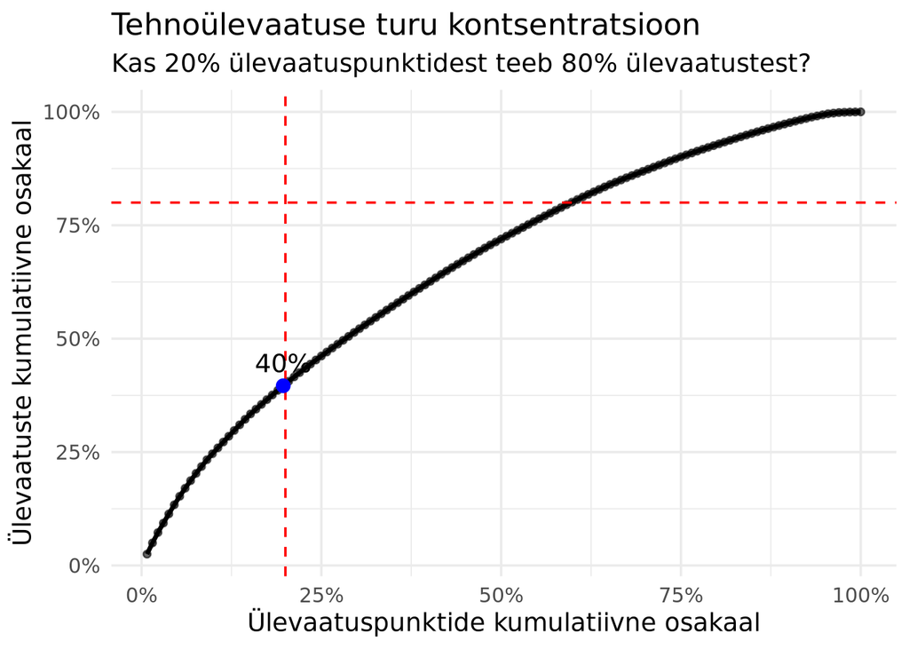

Turg ei järgi klassikalist 80/20 reeglit – 20% ülevaatuspunktidest teeb vaid umbes 40% ülevaatustest. Seega võib arvata, et monopooliat ei ole ja täitsa võib proovida tulla turule. Selleks, et veelgi parem aru saada, kus on nö vabad kohad me edasi vaatame, kus teenindatakse rohkem autosi ja oleks ka hea kanda kõik TÜ punktid kaardi peale. Kuigi selle jaoks oleks vaja saada TÜ asukohad, mida meil ei ole ja tuleb lisa tööd teha. Jättame seda suve tööks.

Edasi vaatame kuhu TÜ rangesus ja kuhu parem mitte käia.

```
## [1] 0.3237237
```

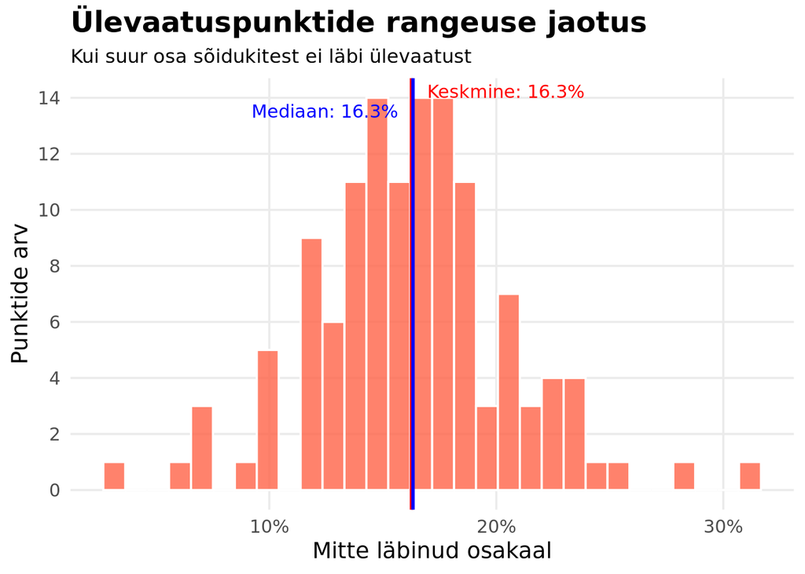

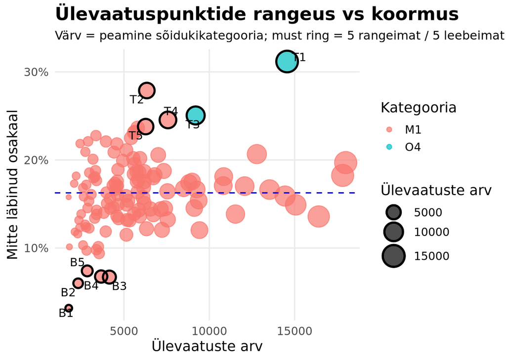

```
## # A tibble: 5 × 6
##      id PUNKTI_KOOD TEHNOYLEVAATUSPUNKT       KATEGOORIA fail_rate n_reviews
##   <int> <chr>       <chr>                     <chr>          <dbl>     <int>
## 1     1 MR          A-Ülevaatus OÜ (Rae)      O4             0.312     14559
## 2     2 MD          A-Ülevaatus OÜ (Maardu)   M1             0.279      6341
## 3     3 MQ          Egesten OÜ (Jüri)         O4             0.251      9201
## 4     4 AZ          A-Ülevaatus OÜ (Lasnamäe) M1             0.245      7578
## 5     5 SE          Evereng OÜ                M1             0.238      6272
```

```
## # A tibble: 6 × 6
##      id PUNKTI_KOOD TEHNOYLEVAATUSPUNKT           KATEGOORIA fail_rate n_reviews
##   <int> <chr>       <chr>                         <chr>          <dbl>     <int>
## 1     1 TU          Aardla Autoteenindus OÜ       M1            0.0317      1766
## 2     2 PJ          Baltic Timber Energy OÜ       M1            0.0600      2316
## 3     3 LC          Thalia LV                     M1            0.0670      4148
## 4     4 BE          L Tehnoülevaatus OÜ (Tallinn) M1            0.0677      3665
## 5     5 LB          Tavs Auto OÜ                  M1            0.0741      2849
## 6     5 LB          Tachograph Invest OÜ (Märjam… M1            0.0741      2849
```

Näeme, et A-Ülevaatusel on üsna palju kliente. Osaliselt see seotud ka sellega, et nende on allahindlus, kui teed broneeringu ja makse läbi webi. Aga nad on kõige rangemad. (Olin ka seda proovinud oma nahal.)

Graafiku järgi näeme, et TÜ rangesus ei ole kuidagi seotud koormusega.

```
## # A tibble: 19 × 3
##    KATEGOORIA fail_rate n_reviews
##    <chr>          <dbl>     <int>
##  1 N3           0.300       34012
##  2 O4           0.290       27024
##  3 L6e          0.283        1221
##  4 N2           0.208        4027
##  5 M1           0.178      436119
##  6 N1           0.172       68839
##  7 M3           0.169        4436
##  8 M1G          0.163       48089
##  9 M2           0.150        1148
## 10 N1G          0.138       12051
## 11 O1           0.0416      26836
## 12 L3e          0.0407      15688
## 13 O2           0.0290      13217
## 14 LM           0.0239       3396
## 15 T1           0.0136       9542
## 16 R3A          0.0131       3597
## 17 TR           0.0128       1562
## 18 T3           0.00771      1815
## 19 T5           0.00689      2177
```

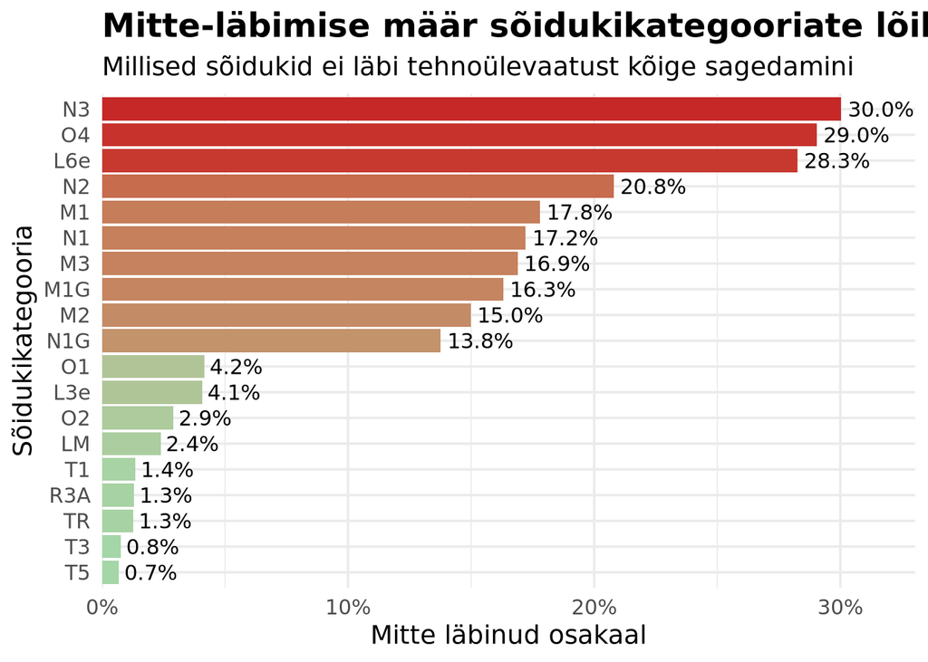